# Lab3, Modelado Simulacion y optimización

### Uniandes

##### Developed by:

## Johan Alexis Bautista Quinayas

## Danny Camilo Muñoz Sanabria

```python
import sympy as sp
import numpy as np
import matplotlib.pyplot as plt
from mpl_toolkits.mplot3d import Axes3D
```

# EJERCICIO 1 (20%): Implementación de Newton Raphson para 2 dimensiones

Implemente en Python los siguientes pasos para encontrar el mínimo o el máximo local de una función usando el método de Newton Raphson para dos dimensiones. Ayuda: use la librería sympy para definir la función, obtener y evaluar la primera y segunda derivada de la función en cuestión.

### 1.1 Defina y grafique la función

$$ f = 3x^3 - 10x^2 - 56x + 50 $$

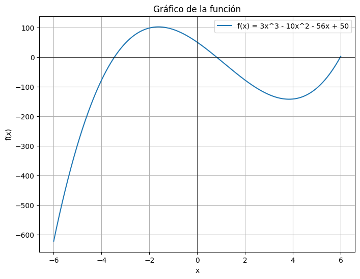

```python
x = sp.symbols('x')

f = 3*x**3 - 10*x**2 - 56*x + 50

f_prime = sp.diff(f, x)
f_double_prime = sp.diff(f_prime, x)

f_lambdified = sp.lambdify(x, f, 'numpy')
X = np.linspace(-6, 6, 400)
Y = f_lambdified(X)

plt.figure(figsize=(8, 6))
plt.plot(X, Y, label='f(x) = 3x^3 - 10x^2 - 56x + 50')
plt.axhline(0, color='black',linewidth=0.5)
plt.axvline(0, color='black',linewidth=0.5)
plt.title('Gráfico de la función')
plt.xlabel('x')
plt.ylabel('f(x)')
plt.legend()
plt.grid(True)
plt.show()
```

### 1.2 Implemente el método de Newton Raphson para dos dimensiones de acuerdo al pseudocódigo:

```python
def newton_raphson_1d(f, f_prime, f_double_prime, x0, alpha=1, tol=0.001):
    xi = x0
    i = 0
    points = [xi]

    while True:
        grad_f_x = f_prime.subs(x, xi)
        hess_f_xx = f_double_prime.subs(x, xi)

        if abs(grad_f_x) < tol:
            break

        delta = grad_f_x / hess_f_xx
        xi -= alpha * delta
        points.append(xi)

        i += 1
        print(f"Iteración {i}: x = {xi}")

    return xi, points

# Primera y segunda derivada
f_prime = sp.diff(f, x)
f_double_prime = sp.diff(f_prime, x)
```

### 1.3 Establezca un punto de arranque entre -6 y 6.

```python
x0 = -3

min_x, points = newton_raphson_1d(f, f_prime, f_double_prime, x0)
print(f"Punto mínimo encontrado: {min_x}")
```

```
Iteración 1: x = -137/74
Iteración 2: x = -475577/292004
Iteración 3: x = -6810476163257/4204993673864
Punto mínimo encontrado: -6810476163257/4204993673864
```

### 1.4 Grafique el mínimo/máximo encontrado sobre la gráfica de la función teórica realizada anteriormente.

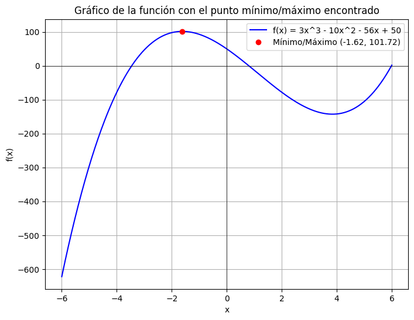

```python
plt.figure(figsize=(8, 6))
plt.plot(X, Y, label='f(x) = 3x^3 - 10x^2 - 56x + 50', color='blue')
plt.axhline(0, color='black',linewidth=0.5)
plt.axvline(0, color='black',linewidth=0.5)
plt.plot(min_x, f_lambdified(min_x), 'ro', label=f'Mínimo/Máximo ({min_x:.2f}, {f_lambdified(min_x):.2f})')
plt.title('Gráfico de la función con el punto mínimo/máximo encontrado')
plt.xlabel('x')
plt.ylabel('f(x)')
plt.legend()
plt.grid(True)
plt.show()
```

### 1.5 Grafique sobre la gráfica de la función teórica los puntos encontrados en cada iteración

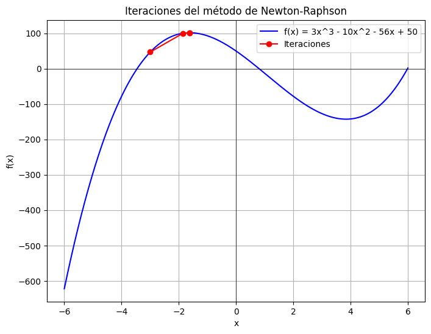

```python
plt.figure(figsize=(8, 6))
plt.plot(X, Y, label='f(x) = 3x^3 - 10x^2 - 56x + 50', color='blue')
plt.axhline(0, color='black',linewidth=0.5)
plt.axvline(0, color='black',linewidth=0.5)
points = np.array(points)
plt.plot(points, f_lambdified(points), 'ro-', label='Iteraciones')
plt.title('Iteraciones del método de Newton-Raphson')
plt.xlabel('x')
plt.ylabel('f(x)')
plt.legend()
plt.grid(True)
plt.show()
```

### 1.6 Realice el paso anterior con α=0.6.

```
Iteración 1: x = -2.31081081081081
Iteración 2: x = -1.93797125339468
Iteración 3: x = -1.75692204690186
Iteración 4: x = -1.67650204863332
Iteración 5: x = -1.64271002080199
Iteración 6: x = -1.62890294724384
Iteración 7: x = -1.62333141562661
Iteración 8: x = -1.62109485643303
Iteración 9: x = -1.62019895117655
Iteración 10: x = -1.61984038336595
Iteración 11: x = -1.61969692328630
Iteración 12: x = -1.61963953397888
Iteración 13: x = -1.61961657741164
```

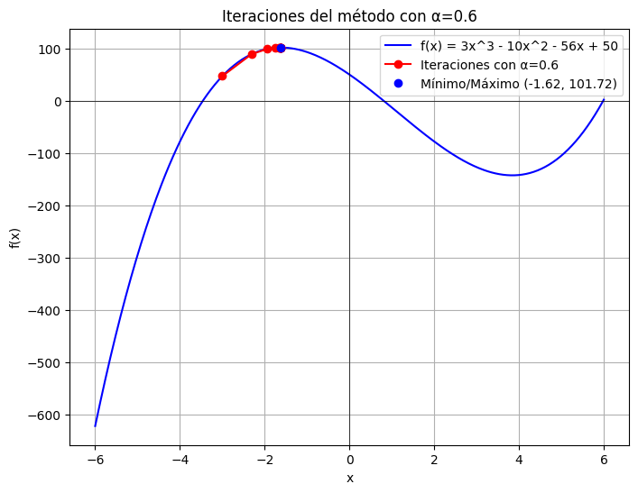

```python
min_x, points = newton_raphson_1d(f, f_prime, f_double_prime, x0, alpha=0.6)

plt.figure(figsize=(8, 6))
plt.plot(X, Y, label='f(x) = 3x^3 - 10x^2 - 56x + 50', color='blue')
plt.axhline(0, color='black',linewidth=0.5)
plt.axvline(0, color='black',linewidth=0.5)
points = np.array(points)
plt.plot(points, f_lambdified(points), 'ro-', label='Iteraciones con α=0.6')
plt.plot(min_x, f_lambdified(min_x), 'bo', label=f'Mínimo/Máximo ({min_x:.2f}, {f_lambdified(min_x):.2f})')
plt.legend()
plt.title('Iteraciones del método con α=0.6')
plt.xlabel('x')
plt.ylabel('f(x)')
plt.grid(True)
plt.show()
```

# EJERCICIO 2 (30%): Implementación de Newton Raphson para encontrar todos los máximos y mínimos de una función

Diseñe un programa que halle y muestre gráficamente todos los mínimos y máximos locales de una función para luego determinar el minino y máximo global de la misma dentro del rango de la figura (entre -3 y 3). Use los métodos de Newton Raphson o los Gradientes para realizar lo solicitado.

La función a implementar es:
$$ y = x^5 - 8x^3 + 10x + 6 $$

```python
x = sp.symbols('x')

f = x**5 - 8*x**3 + 10*x + 6

f_prime = sp.diff(f, x)
f_double_prime = sp.diff(f_prime, x)

f_lambdified = sp.lambdify(x, f, 'numpy')
f_prime_lambdified = sp.lambdify(x, f_prime, 'numpy')
f_double_prime_lambdified = sp.lambdify(x, f_double_prime, 'numpy')
```

```python
def newton_raphson(f_prime, f_double_prime, x0, tol=0.001, max_iter=1000):
    xi = x0
    for _ in range(max_iter):
        f_prime_val = f_prime_lambdified(xi)
        f_double_prime_val = f_double_prime_lambdified(xi)

        if abs(f_prime_val) < tol:
            return xi

        xi -= f_prime_val / f_double_prime_val
    return xi

def find_critical_points(f_prime, f_double_prime, x_values):
    critical_points = []
    for x0 in x_values:
        critical_point = newton_raphson(f_prime, f_double_prime, x0)
        if critical_point not in critical_points:
            critical_points.append(critical_point)
    return critical_points

x_values = np.linspace(-3, 3, 10)

critical_points = find_critical_points(f_prime, f_double_prime, x_values)
print(f"Puntos críticos encontrados: {critical_points}")
```

```
Puntos críticos encontrados: [-2.083044113731595, -2.0830439133373444, -2.0830448983374192, -0.678916872445483, -0.6789234450856525, 0.6789234450856525, 0.678916872445483, 2.0830448983374197, 2.0830439133373444, 2.083044113731595]
```

Calculamos los puntos críticos de la función mediante el método de Newton-Raphson. Estos puntos críticos son aquellos donde la primera derivada de la función se aproxima a cero, indicando posibles máximos, mínimos o puntos de inflexión. Los puntos críticos encontrados son los que se muestran en el output.

```python
local_maxima = []
local_minima = []

for point in critical_points:
    second_derivative = f_double_prime_lambdified(point)
    if second_derivative > 0:
        local_minima.append(point)
    elif second_derivative < 0:
        local_maxima.append(point)

print(f"Máximos locales: {local_maxima}")
print(f"Mínimos locales: {local_minima}")

all_points = local_maxima + local_minima + [-3, 3]
f_values = [f_lambdified(p) for p in all_points]
max_global = all_points[np.argmax(f_values)]
min_global = all_points[np.argmin(f_values)]

print(f"Máximo global en x = {max_global}")
print(f"Mínimo global en x = {min_global}")
```

```
Máximos locales: [-2.083044113731595, -2.0830439133373444, -2.0830448983374192, 0.6789234450856525, 0.678916872445483]
Mínimos locales: [-0.678916872445483, -0.6789234450856525, 2.0830448983374197, 2.0830439133373444, 2.083044113731595]
Máximo global en x = 3
Mínimo global en x = -3
```

Aquí hacemos uso de la segunda derivada para clasificar los puntos críticos como máximos o mínimos locales. Si la segunda derivada en un punto crítico es negativa, ese punto es un máximo local; si es positiva, es un mínimo local. También se identifican el máximo y mínimo global evaluando los valores en los extremos del intervalo [−3,3][−3,3].

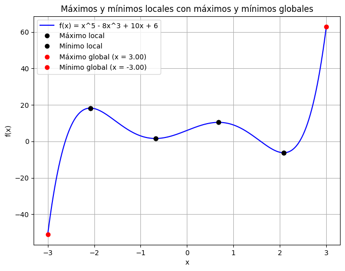

```python
X = np.linspace(-3, 3, 400)
Y = f_lambdified(X)

plt.figure(figsize=(8, 6))
plt.plot(X, Y, label='f(x) = x^5 - 8x^3 + 10x + 6', color='blue')

for point in local_maxima:
    plt.plot(point, f_lambdified(point), 'ko', label='Máximo local' if point == local_maxima[0] else "")
for point in local_minima:
    plt.plot(point, f_lambdified(point), 'ko', label='Mínimo local' if point == local_minima[0] else "")

plt.plot(max_global, f_lambdified(max_global), 'ro', label=f'Máximo global (x = {max_global:.2f})')
plt.plot(min_global, f_lambdified(min_global), 'ro', label=f'Mínimo global (x = {min_global:.2f})')

plt.title('Máximos y mínimos locales con máximos y mínimos globales')
plt.xlabel('x')
plt.ylabel('f(x)')
plt.legend()
plt.grid(True)
plt.show()
```

En esta gráfica se muestra la función en el intervalo [−3,3] con los máximos y mínimos locales representados en color negro. El máximo global se marca en color rojo en x=3, y el mínimo global en x=−3.

# EJERCICIO 3 (50%): Implementación de Newton Raphson para 3 dimensiones

### 3.1 Teóricamente, defina y grafique la superficie z

La superficie z definida como: $$ z(x,y)=(x−1)^2+100(y−x^2)^2 $$

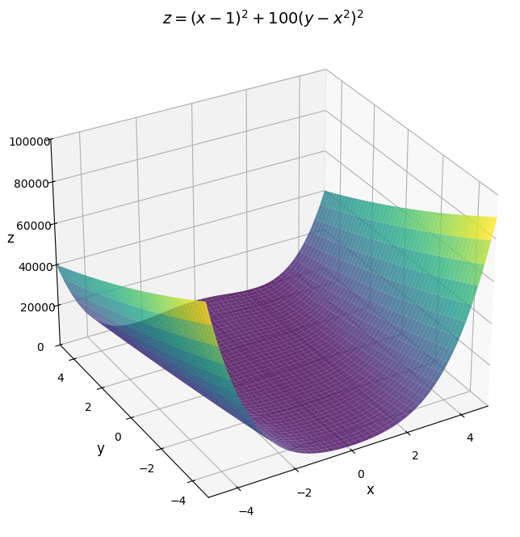

```python
def rosenbrock(x, y):
    return (x - 1)**2 + 100 * (y - x**2)**2

x_vals = np.linspace(-5, 5, 400)
y_vals = np.linspace(-5, 5, 400)
X, Y = np.meshgrid(x_vals, y_vals)
Z = rosenbrock(X, Y)

fig = plt.figure(figsize=(10, 8))
ax = fig.add_subplot(111, projection='3d')
ax.plot_surface(X, Y, Z, cmap='viridis', alpha=0.8, edgecolor='none')

ax.set_xlim([-5, 5])
ax.set_ylim([-5, 5])
ax.set_zlim([0, 100000])
ax.view_init(elev=30, azim=240)

ax.set_title(r'$z = (x-1)^2 + 100(y-x^2)^2$', fontsize=14)
ax.set_xlabel('x', fontsize=12)
ax.set_ylabel('y', fontsize=12)
ax.set_zlabel('z', fontsize=12)
plt.show()
```

### 3.2 Implemente el método de Newton Raphson para 3 dimensiones de acuerdo al siguiente pseudocódigo:

```python
def grad_rosenbrock(x, y):
    df_dx = -2 * (1 - x) - 400 * x * (y - x**2)
    df_dy = 200 * (y - x**2)
    return np.array([df_dx, df_dy])

def hessian_rosenbrock(x, y):
    d2f_dx2 = 2 - 400 * y + 1200 * x**2
    d2f_dxdy = -400 * x
    d2f_dy2 = 200
    return np.array([[d2f_dx2, d2f_dxdy], [d2f_dxdy, d2f_dy2]])

def newton_raphson_3d_count(x0, y0, alpha=1, tol=1e-6, max_iter=100):
    xi, yi = x0, y0
    path = [(xi, yi)]

    for i in range(max_iter):
        grad = grad_rosenbrock(xi, yi)
        hess = hessian_rosenbrock(xi, yi)

        if np.linalg.norm(grad) < tol:
            return xi, yi, path, i

        delta = np.linalg.inv(hess).dot(grad)
        xi = xi - alpha * delta[0]
        yi = yi - alpha * delta[1]

        path.append((xi, yi))

    return xi, yi, path, max_iter
```

### 3.3 Sintonice el paso (α) para que el mínimo se encuentre rápidamente.

Se recomienda un punto de arranque ubicado en x=0, y=10.

```python
alpha_values = [0.1, 0.3, 0.5, 0.8, 1.0]
x_start, y_start = 0, 10

for alpha in alpha_values:
    x_min, y_min, path, iterations = newton_raphson_3d_count(x_start, y_start, alpha=alpha)
    print(f"Alpha = {alpha}, Iteraciones = {iterations}, Mínimo encontrado en x = {x_min:.5f}, y = {y_min:.5f}")
```

```
Alpha = 0.1, Iteraciones = 100, Mínimo encontrado en x = 0.50687, y = 0.25019
Alpha = 0.3, Iteraciones = 84, Mínimo encontrado en x = 1.00000, y = 1.00000
Alpha = 0.5, Iteraciones = 53, Mínimo encontrado en x = 1.00000, y = 1.00000
Alpha = 0.8, Iteraciones = 31, Mínimo encontrado en x = 1.00000, y = 1.00000
Alpha = 1.0, Iteraciones = 5, Mínimo encontrado en x = 1.00000, y = 1.00000
```

El valor óptimo de 𝛼 para este problema es 𝛼=1.0, ya que converge al mínimo global en solo 5 iteraciones, mucho más rápido que los otros valores.

### 3.4 Grafique el mínimo encontrado sobre la gráfica de la función teórica realizada anteriormente.

### 3.5 Grafique sobre la gráfica de la función teórica los puntos encontrados de cada iteración.

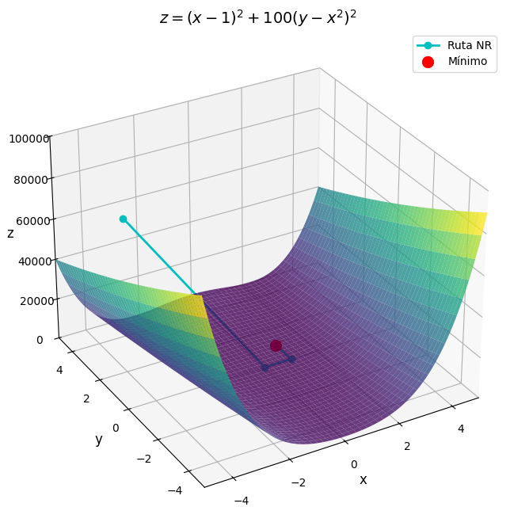

```python
fig = plt.figure(figsize=(10, 8))
ax = fig.add_subplot(111, projection='3d')

ax.plot_surface(X, Y, Z, cmap='viridis', alpha=0.8, edgecolor='none')

path = np.array(path)
z_path = rosenbrock(path[:, 0], path[:, 1])
ax.plot(path[:, 0], path[:, 1], z_path, 'c-', marker='o', label="Ruta NR", linewidth=2, markersize=6)

z_min = rosenbrock(x_min, y_min)
ax.plot([x_min], [y_min], [z_min], 'ro', markersize=10, label="Mínimo")

ax.set_xlim([-5, 5])
ax.set_ylim([-5, 5])
ax.set_zlim([0, 100000])

ax.view_init(elev=30, azim=240)

# Etiquetas y título
ax.set_title(r'$z = (x-1)^2 + 100(y-x^2)^2$', fontsize=14)
ax.set_xlabel('x', fontsize=12)
ax.set_ylabel('y', fontsize=12)
ax.set_zlabel('z', fontsize=12)
ax.legend()
plt.show()
```

### Conclusiones:

- Mínimo global: El algoritmo ha encontrado el mínimo en x=1,y=1, que es el valor esperado para la función de Rosenbrock.
- Convergencia rápida: Con α=1.0, el algoritmo alcanza el mínimo en solo 5 iteraciones